# CP03

Jose López Galdón

2020-11-05

## CARGAMOS LOS DATOS

Visualizamos los datos.

```r
raw_data
```

```
## # A tibble: 65 x 11
##    Country Overall Issues Explain Evidence Interest Support Income Health    Edu
##    <chr>     <dbl>  <dbl>   <dbl>    <dbl>    <dbl>   <dbl>  <dbl>  <dbl>  <dbl>
##  1 Albania      NA     NA      NA       NA       NA      NA  0.599  0.886  0.716
##  2 Argent~     391    395     386      385      567     506  0.678  0.868  0.786
##  3 Austra~     527    535     520      531      465     487  0.826  0.965  0.978
##  4 Austria     511    505     516      505      507     515  0.835  0.944  0.824
##  5 Azerba~     382    353     412      344      612     542  0.566  0.78  NA
##  6 Belgium     510    515     503      516      503     492  0.831  0.935  0.868
##  7 Brazil      390    398     390      378      592     519  0.637  0.818  0.646
##  8 Bulgar~     434    427     444      417      523     527  0.663  0.829  0.778
##  9 Canada      534    532     531      542      469     501  0.84   0.951  0.902
## 10 Chile       438    444     432      440      591     564  0.673  0.923  0.764
## # ... with 55 more rows, and 1 more variable: HDI <dbl>
```

## LIMPIEZA DEL DATASET

### Selección de variables

Las variables clave son las siguientes:

- Overall Science Score (average score for 15 year olds)
- Interest in science
- Support for scientific inquiry
- Income Index
- Health Index
- Education Index
- Human Development Index (composed of the Income index, Health Index, and Education Index)

```r
raw_data %<>%
  select(Country, Overall, Interest, Support, Income, Health, Edu, HDI)
```

### Renombrar columnas

Comenzaremos cambiando los nombres de las columnas a minusculas para poder trabajar más cómodamente con las variables

```r
# Para ello usaremos la funcion clean_names() que nos cambiará aquellos valores que nos puedan ocasionar problemas a la hora de trabajar con las variables

raw_data %<>% clean_names()   # %<>%: Evita poner "raw_data <- raw_data %>%"
colnames(raw_data)
```

```
## [1] "country"  "overall"  "interest" "support"  "income"   "health"   "edu"
## [8] "hdi"
```

Una vez tenemos los nombres de las variables en el formato correcto, ya podemos comenzar con el tratamiento de *duplicados* y de *valores nulos*

### Data wrangling

La manipulación de datos es el proceso de limpieza y unificación de conjuntos de datos complejos para el análisis, lo que a su vez aumenta la productividad dentro de una organización.

En esta ocasión tenemos un dataset reducido con bastantes NaN, por lo que si eliminamos estos valores con `drop_na()` perderemos mucha información, es por ello por lo que cambiaremos los nulos por la media.

```r
# Valores duplicados: los eliminamos

raw_data %<>% distinct(country, .keep_all = T)

# Valores nulos:

summarise_all(raw_data, funs(sum(is.na(.))))
```

```
## # A tibble: 1 x 8
##   country overall interest support income health   edu   hdi
##     <int>   <int>    <int>   <int>  <int>  <int> <int> <int>
## 1       0       8        8       8      4      4     6     6
```

```r
  # Como existen muchos valores nulos los sustituimos por la media con la funcion na_mean() de la libreria imputeTS

raw_data <- na_mean(raw_data)
```

Por lo tanto, ya tenemos nuestro DF limpio y listo para trabajar

```r
data <- raw_data

View(data)

attach(data)
```

## EDA

A continuación, realizaremos un resumen estadístico de las variables y graficaremos histogramas con sus densidades, correlaciones y gráficos de dispersión.

### Estadísticos relevantes

```r
skim(data)
```

Data summary

| Name | data |
| --- | --- |
| Number of rows | 65 |
| Number of columns | 8 |
| _______________________ |  |
| Column type frequency: |  |
| character | 1 |
| numeric | 7 |
| ________________________ |  |
| Group variables | None |

**Variable type: character**

| skim_variable | n_missing | complete_rate | min | max | empty | n_unique | whitespace |
| --- | --- | --- | --- | --- | --- | --- | --- |
| country | 0 | 1 | 4 | 24 | 0 | 65 | 0 |

**Variable type: numeric**

| skim_variable | n_missing | complete_rate | mean | sd | p0 | p25 | p50 | p75 | p100 | hist |
| --- | --- | --- | --- | --- | --- | --- | --- | --- | --- | --- |
| overall | 0 | 1 | 473.14 | 51.06 | 322.00 | 436.00 | 487.00 | 511.00 | 563.00 | ▁▂▂▇▃ |
| interest | 0 | 1 | 528.16 | 46.62 | 448.00 | 503.00 | 528.16 | 549.00 | 644.00 | ▆▇▇▃▂ |
| support | 0 | 1 | 512.18 | 24.40 | 447.00 | 497.00 | 512.18 | 527.00 | 569.00 | ▂▃▇▅▂ |
| income | 0 | 1 | 0.74 | 0.11 | 0.41 | 0.66 | 0.74 | 0.83 | 0.94 | ▁▂▆▇▅ |
| health | 0 | 1 | 0.89 | 0.06 | 0.72 | 0.84 | 0.89 | 0.94 | 0.99 | ▂▂▇▇▇ |
| edu | 0 | 1 | 0.80 | 0.11 | 0.54 | 0.74 | 0.80 | 0.87 | 0.99 | ▂▃▇▇▅ |
| hdi | 0 | 1 | 0.81 | 0.08 | 0.58 | 0.75 | 0.81 | 0.87 | 0.94 | ▁▃▆▇▆ |

### Correlaciones

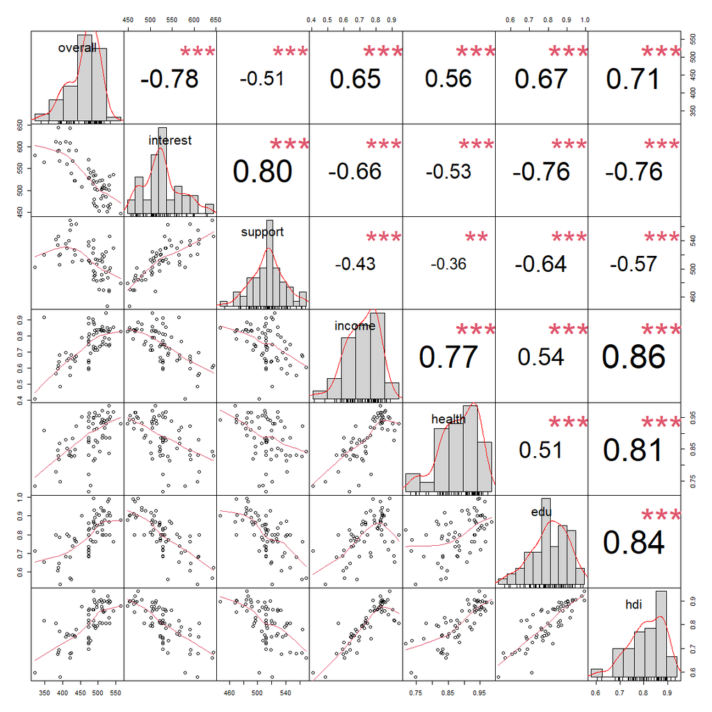

```r
chart.Correlation(data %>%
               select_at(vars(-country)),
               histogram = TRUE, pch = 19)
```

Vemos como existenciertas correlaciones, como la del hdi (Índice de Desarrollo Humano) con la educación, la salud o la renta.

## SPLINES SUAVIZADO

### Teoría

Son las splines de regresión, que se crean especificando un conjunto de nudos, produciendo una secuencia de funciones de base, y luego usando mínimos cuadrados para estimar los coeficientes de spline.

Suavizar splines es un enfoque diferente para crear una spline. Hay que encontrar una función que haga que el RSS sea razonablemente pequeño, pero que también sea fluido.

Una forma de hacerlo es utilizar un parámetro de ajuste lambda que penaliza la variabilidad en la función:

- Si lambda = 0, el término de penalización no tiene ningún efecto, y la función estará turbia e interpolará cada valor.
- Cuando lamba = infinito, la función será perfectamente suave, una línea recta (en realidad, una línea lineal de mínimos cuadrados).

### Práctica

A continuación, calcularemos por cross_validation los grados de libertad óptimos de cada variable.

```r
# INTEREST

fit_interest <- smooth.spline(x = interest, y = overall, cv = TRUE)
fit_interest$df
```

```
## [1] 4.750171
```

```r
# SUPPORT

fit_support <- smooth.spline(x = support, y = overall, cv = TRUE)
fit_support$df
```

```
## [1] 2.001243
```

```r
# INCOME

fit_income <- smooth.spline(x = income, y = overall, cv = TRUE)
fit_income$df
```

```
## [1] 4.244952
```

```r
# HEALTH

fit_health <- smooth.spline(x = health, y = overall, cv = TRUE)
fit_health$df
```

```
## [1] 2.002844
```

```r
# EDU

fit_edu <- smooth.spline(x = edu, y = overall, cv = TRUE)
fit_edu$df
```

```
## [1] 2.002385
```

```r
# HDI

fit_hdi <- smooth.spline(x = hdi, y = overall, cv = TRUE)
fit_hdi$df
```

```
## [1] 8.603228
```

Una vez tenemos los resultados de los grados de libertad ideales para cada variable por CV:

- `Interest: 4.750171`
- `Support: 2.001243`
- `Income: 4.244952`
- `Health: 2.002844`
- `Edu: 2.002385`
- `HDI: 8.603228`

Comprobaremos la diferencia de haber obtenido por CV los grados de libertado o introducirlos manualmente al azar:

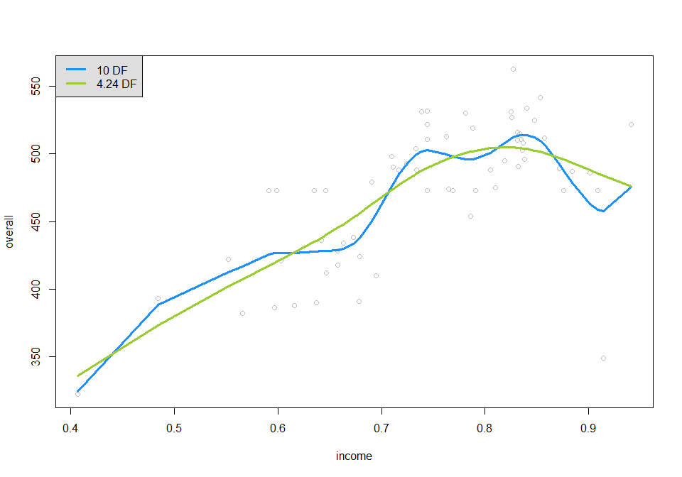

```r
# Para nuestro ejemplo cogeremos la variable interest:

  # Pirmero, generamos un smooth.spline con 10 grados de libertad (este número es al azar)

fit_df10_income <- smooth.spline(x = income, y = overall, df = 10)

  # Ploteamos ambos modelos para comparar
plot(income, overall, col = 'gray')
  lines(fit_df10_income, col = 'dodgerblue', lwd = 3)   # Plot del modelo con 10 grados de libertad
  lines(fit_income, col = 'olivedrab3', lwd = 3)            # Plot del modelo con los grados de libertad por CV
  legend('topleft', legend = c('10 DF', '4.24 DF'),   # Parámetros de la leyenda
       col = c('dodgerblue', 'olivedrab3'), lty = 1, lwd = 3, cex = 1, bg = 'gray87')
```

Como podemos observar, al establecer los grados de libertad de manera manual corremos el riesgo de sufrir overfitting o underfitting, así en la línea azul bemos como hay unas ondulaciones excesivas que no generalizan de manera adecuada, esto es producto de tener un elevado número de grados de libertad, si por el contrario, reducimos los grados de libertad en exceso tenderemos a una línea recta, por lo que tendremos underfitting.

## MODELOS ADITIVOS GENERALIZADOS (GAM)

### Teoría

Los splines se explican desde la perspectiva de adaptar un modelo a la respuesta Y con un único predictor X. Exploramos el problema de la flexibilidad prediciendo Y sobre la base de varios predictores. Esta es nuevamente una extensión del modelo lineal simple.

Los modelos GAM proporcionan un marco general para extender el modelo lineal al permitir funciones no lineales de cada variable, mientras se mantiene la capacidad de adición.

### Práctica

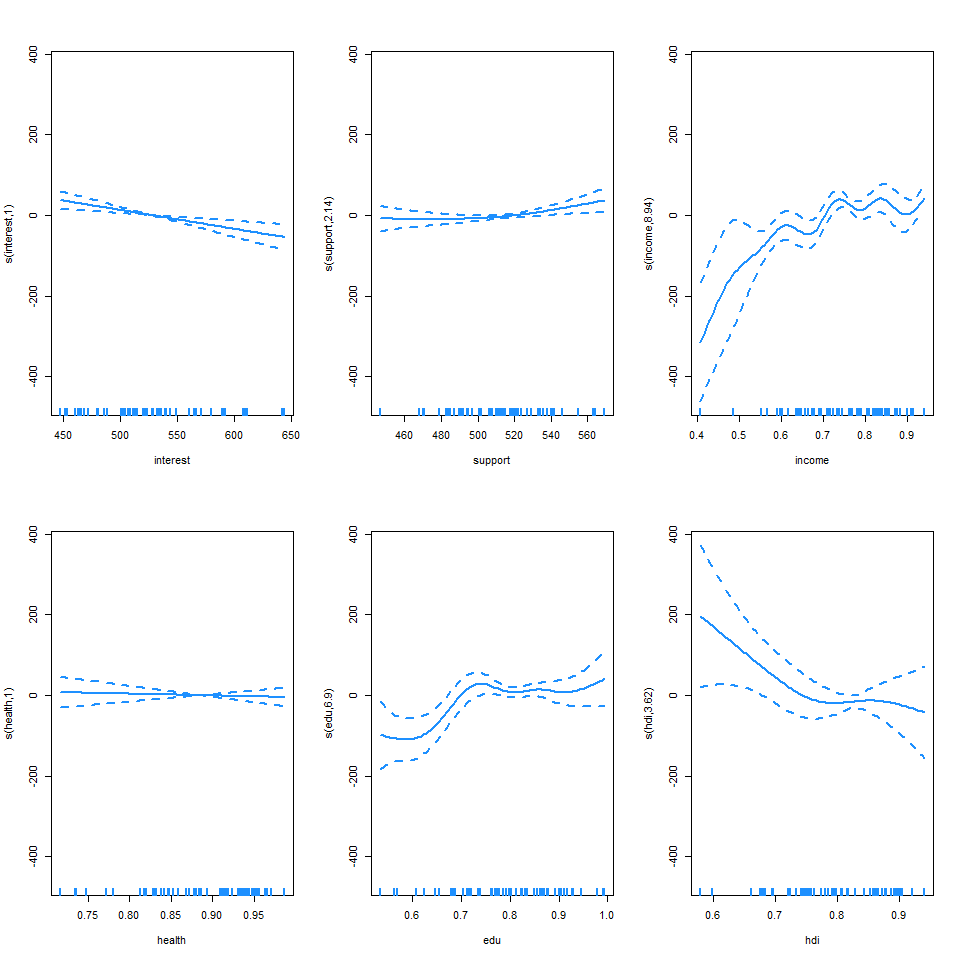

```r
modelo_gam_1 <- gam(overall ~ s(interest) + s(support) + s(income) + s(health) + s(edu) + s(hdi), data = data)

par(mfrow = c(2, 3))
plot(modelo_gam_1, se = TRUE, col = 'dodgerblue', lwd = 2)
```